# Plotting and Visualization in R

Rochelle Terman

Fall 2015

> “Make it informative, then make it pretty”

# Plotting in R

En R, il y a deux types d’outils principaux pour créer des graphes : 1. base, qui vient avec toutes les installations de R 2. ggplot2, a package à part entière

Ils en existent d’autres, mais celles-ci sont les plus populaires.

### setup environment

```r
# remove all objects
rm(list=ls())

# set working directory
setwd(dir="./")
```

### The dataset

Pour les exemples à venir, nous allons charger le jeu de données “gapminder”. Il recense des informations comme l’espérance de vie, le PIB, …, par pays et années.

```r
dat <- read.csv("data/gapminder-FiveYearData.csv", stringsAsFactors = F)
dat
```

```
##                    country year       pop continent lifeExp  gdpPercap
## 1              Afghanistan 1952   8425333      Asia  28.801   779.4453
## 2              Afghanistan 1957   9240934      Asia  30.332   820.8530
## 3              Afghanistan 1962  10267083      Asia  31.997   853.1007
## 4              Afghanistan 1967  11537966      Asia  34.020   836.1971
## 5              Afghanistan 1972  13079460      Asia  36.088   739.9811
## 6              Afghanistan 1977  14880372      Asia  38.438   786.1134
## 7              Afghanistan 1982  12881816      Asia  39.854   978.0114
## 8              Afghanistan 1987  13867957      Asia  40.822   852.3959
## 9              Afghanistan 1992  16317921      Asia  41.674   649.3414
## 10             Afghanistan 1997  22227415      Asia  41.763   635.3414
## 11             Afghanistan 2002  25268405      Asia  42.129   726.7341
## 12             Afghanistan 2007  31889923      Asia  43.828   974.5803
## 13                 Albania 1952   1282697    Europe  55.230  1601.0561
## 14                 Albania 1957   1476505    Europe  59.280  1942.2842
```

[output cut: 153 more lines]

# 1. R base graphics

- Les appels de base ont cette forme là :

```r
plot(x=)
```

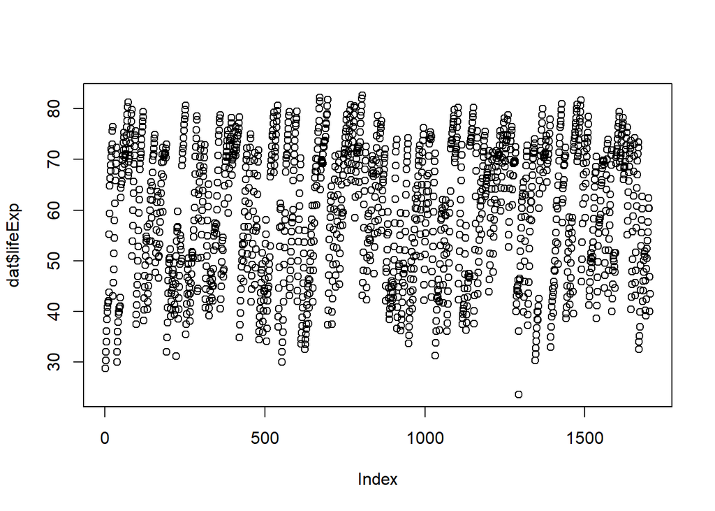

```r
# Si on trace un vecteur seul, R va supposer que l'indice de chacun des éléments constituent les abscisses.
plot(x = dat$lifeExp)
```

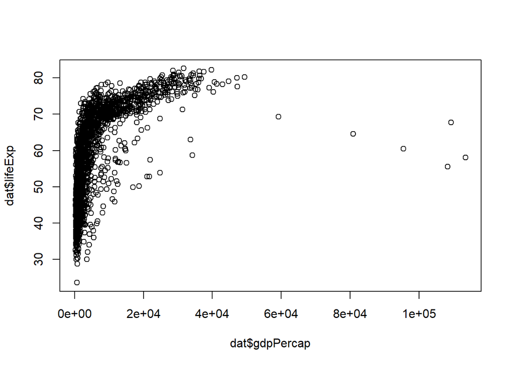

```r
plot(x = dat$gdpPercap, y = dat$lifeExp)
```

### 1a. Scatter et line plots

- L’argument “type” peut prendre les indicateurs suivants
- “p” – point/scatter plots (comportement par défaut)

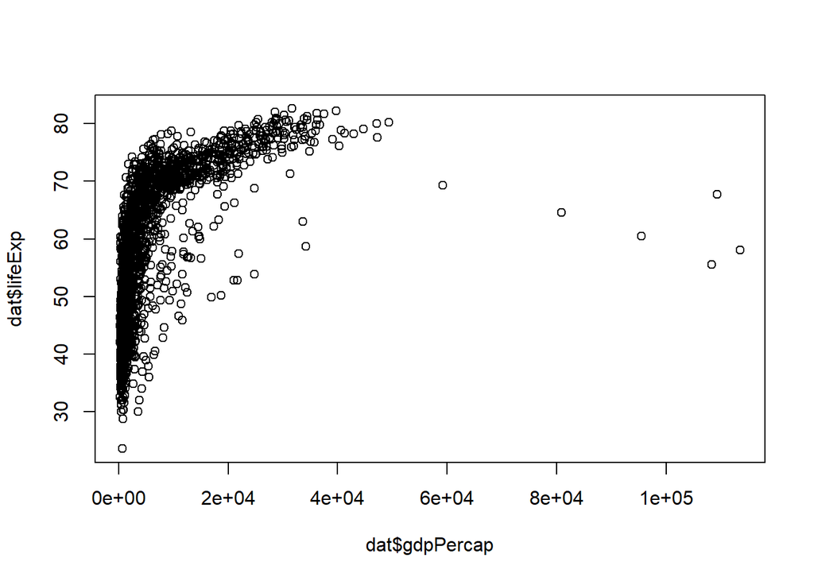

```r
plot(x = dat$gdpPercap, y = dat$lifeExp, type="p")
```

- “l” – Une courbe

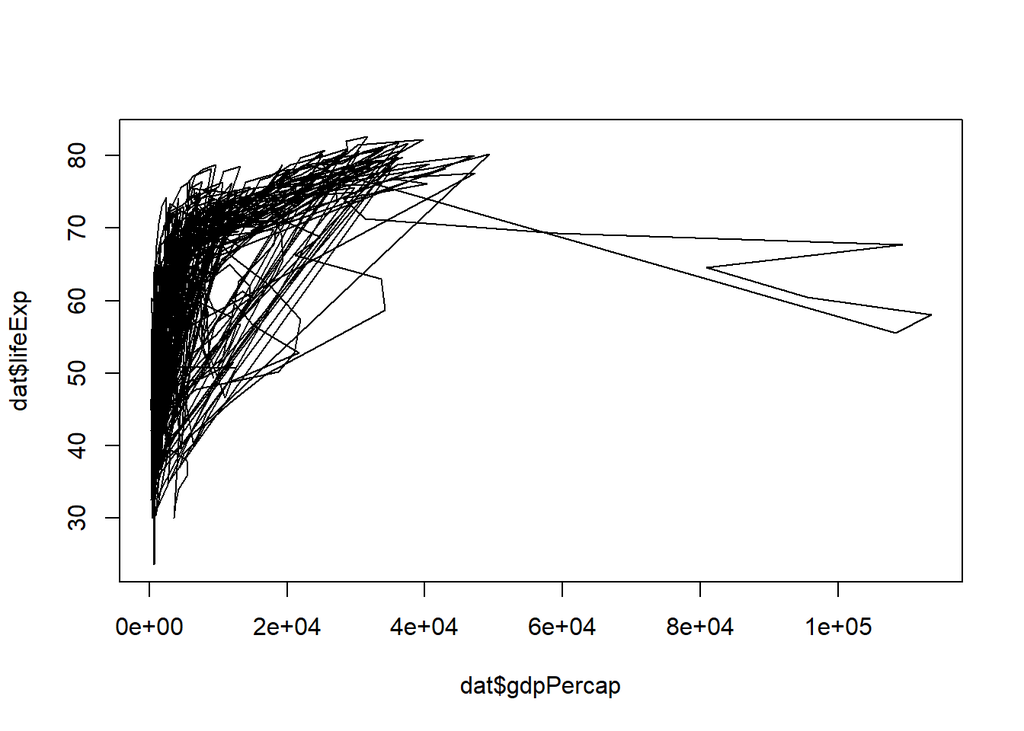

```r
# Attention ! Line n'associe pas une courbe de régression, elle relie juste les points
plot(x = dat$gdpPercap, y = dat$lifeExp, type="l")
```

- “b” – A la fois les lignes et les points

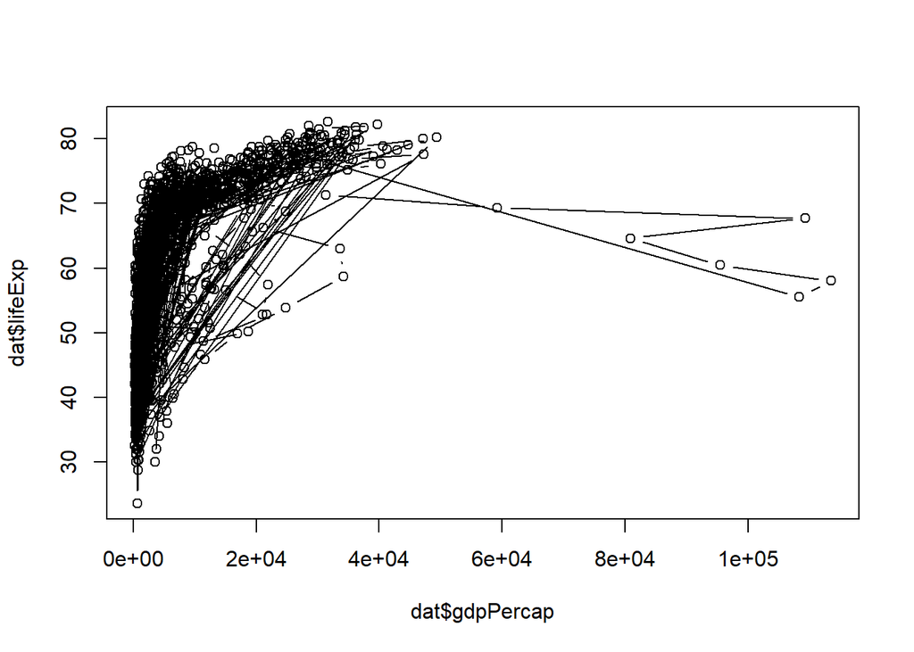

```r
plot(x = dat$gdpPercap, y = dat$lifeExp, type="b")
```

### 1b. Histogrammes et courbes de densité

- Certains types de courbes requièrent d’autres arguments :
- Ex) Histograms

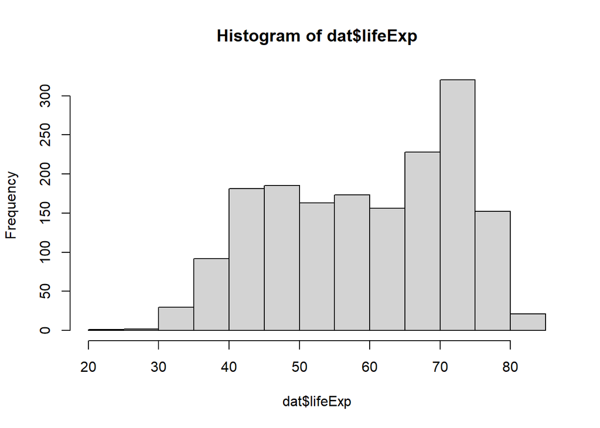

```r
hist(x=dat$lifeExp)
```

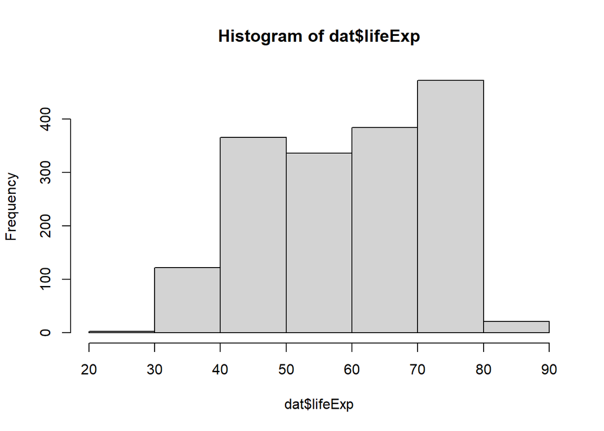

```r
hist(x=dat$lifeExp, breaks=5)
```

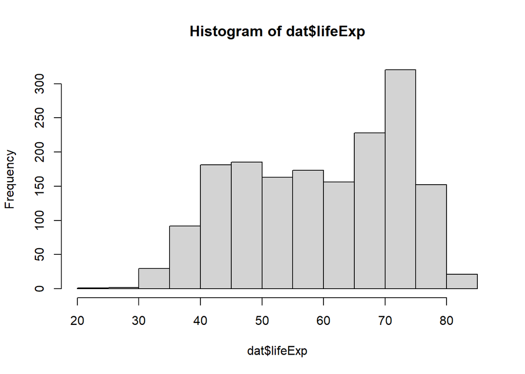

```r
hist(x=dat$lifeExp, breaks=10)
```

- Ex) Density plots

```r
# Créer un objet "densité" (Attention à bien enlever les valeurs manquantes)
age.density<-density(x=dat$lifeExp, na.rm=T)
# Vérifier la classe de l'objet
class(age.density)
```

```
## [1] "density"
```

```r
# Inspecter l'objet
age.density
```

```
##
## Call:
##  density.default(x = dat$lifeExp, na.rm = T)
##
## Data: dat$lifeExp (1704 obs.);   Bandwidth 'bw' = 2.625
##
##        x               y
##  Min.   :15.72   Min.   :0.000001
##  1st Qu.:34.41   1st Qu.:0.001079
##  Median :53.10   Median :0.017034
##  Mean   :53.10   Mean   :0.013364
##  3rd Qu.:71.79   3rd Qu.:0.020987
##  Max.   :90.48   Max.   :0.034870
```

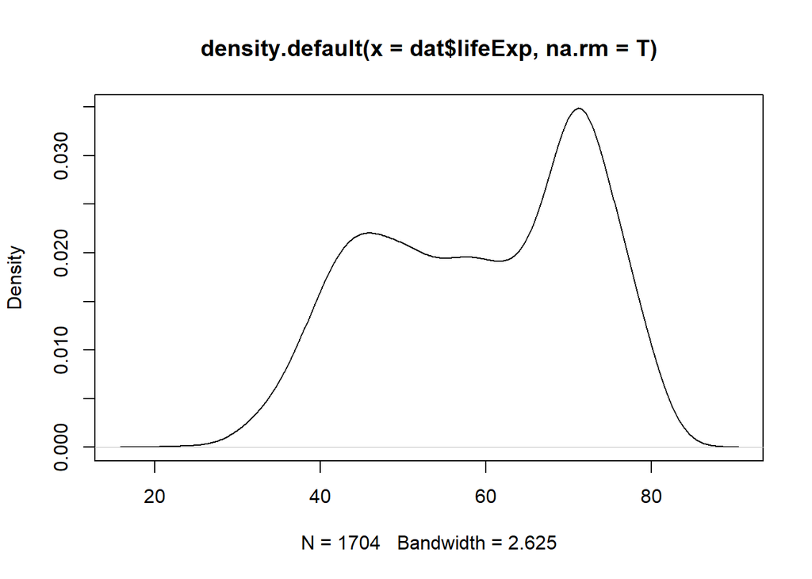

```r
# Tracer l'objet densité
plot(x=age.density)
```

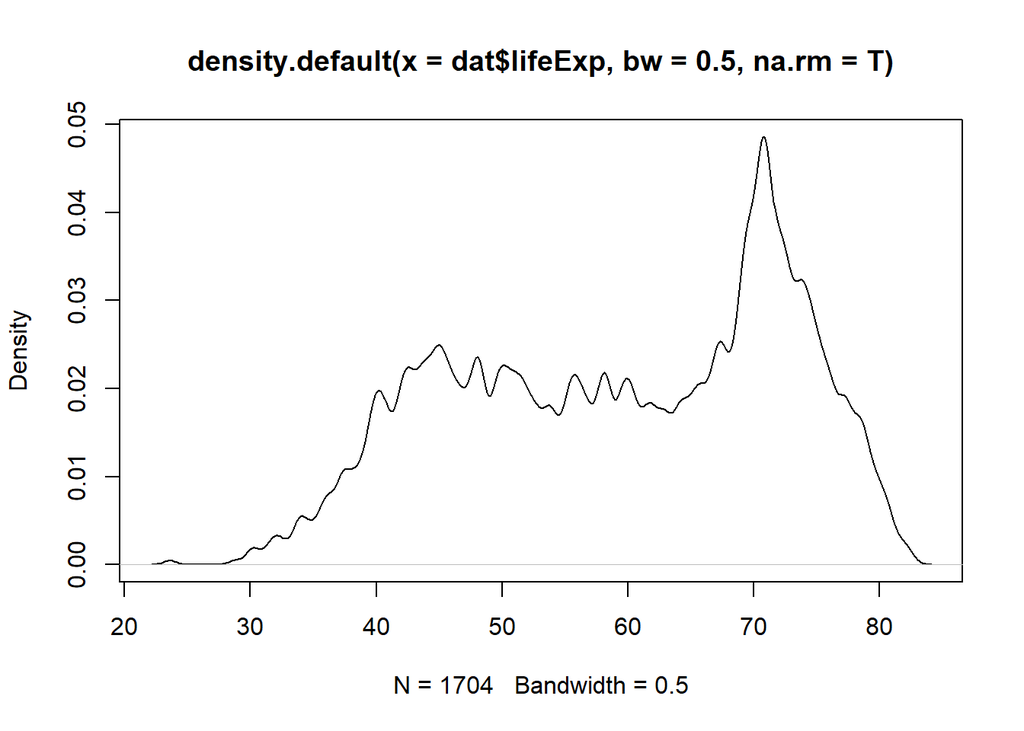

```r
# Bande passante de 0.5
plot(x=density(x=dat$lifeExp, bw=.5, na.rm=T))
```

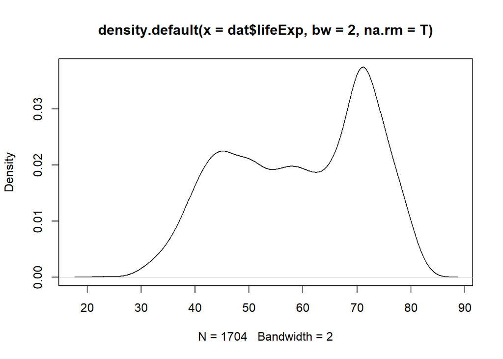

```r
# Bande passante de 2
plot(x=density(x=dat$lifeExp, bw=2, na.rm=T))
```

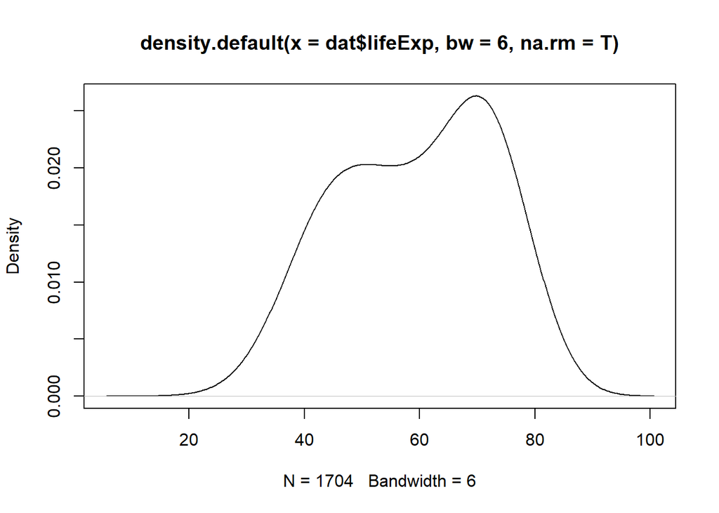

```r
# Bande passante de 6
plot(x=density(x=dat$lifeExp, bw=6, na.rm=T))
```

### 1c. Titres et légendes

- Utilisation basique avec titres et légendes

```r
plot(x=, y=, type="", xlab="", ylab="", main="")
```

- From the previous example

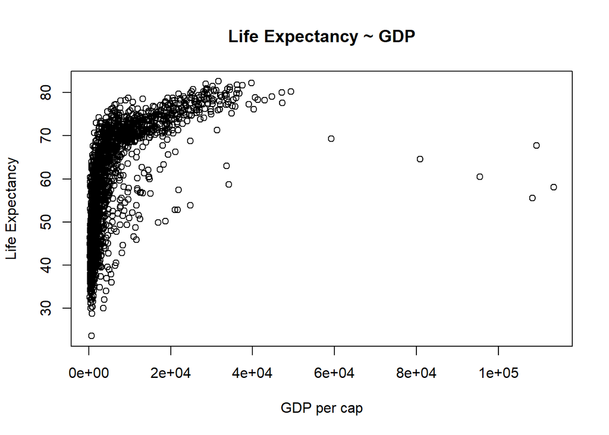

```r
plot(x = dat$gdpPercap, y = dat$lifeExp, type="p", xlab="GDP per cap", ylab="Life Expectancy", main="Life Expectancy ~ GDP") # Add labels for axes and overall plot
```

# 2. ggplot2

### 2a. Pourquoi ggplot?

- Du code plus élégant et plus compact * Esthétiquement plus agréable*  Très efficace pour l’exploration des données
- Suit une grammaire définie
- Défini chaque composante basique pour construire une phrase

### 2b. Grammaire

L’appel général des fonctions ggplot se fait comme suit :

```r
ggplot(data=, aes(x=, y=), color=, size=,) + geom_xxxx()+geom_yyyy()
```

La *grammaire* implique des briques basiques :

1. **Data**: une data.frame
2. **Aes**thetics: Comment les données sont représentées visuellement. Un mapping entre les variables de chaque axe, les couleurs, tailles, formes, etc.
3. **Geom**etry: Les objets géométriques sur le graphe : points, lignes, polygones, etc.

La clé pour comprendre ggplot2 est de penser le graphe en couches : comme pour l’édition d’image sur Photoshop ou Illustrator.

Passons aux exemples :

```r
library(ggplot2)
ggplot(data = dat, aes(x = gdpPercap, y = lifeExp)) +
  geom_point()
```

[output not shown]

L’appel à ggplot simplement ne suffit pas à dessiner une figure :

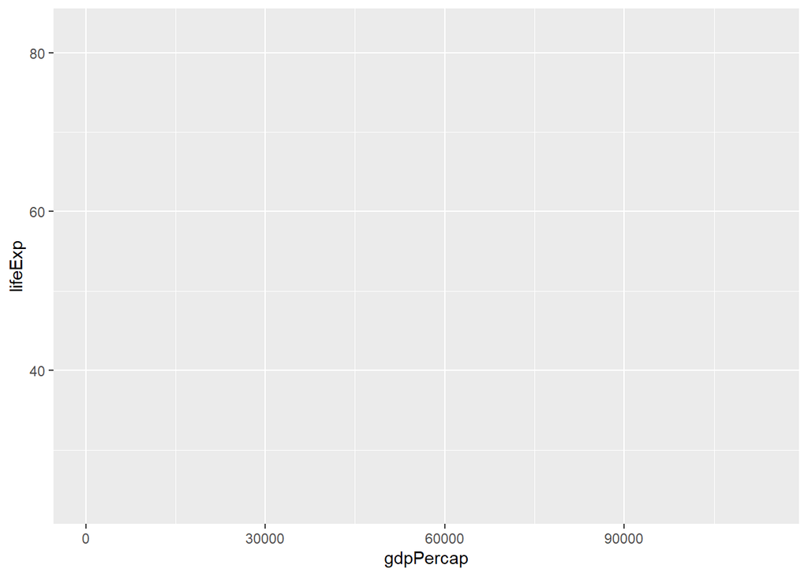

```r
ggplot(data = dat, aes(x = gdpPercap, y = lifeExp))
```

Il faut lui préciser comment nous voulons représenter les données :

```r
ggplot(data = dat, aes(x = gdpPercap, y = lifeExp)) + geom_point()
```

[output not shown]

```r
# same as
my_plot <- ggplot(data = dat, aes(x = gdpPercap, y = lifeExp))
my_plot + geom_point()
```

[output not shown]

### 2c. Anatomie d’`aes`

La fonction aes gère aussi la couleur : on peut lui préciser une des colonnes des données pour en faire des facteurs :

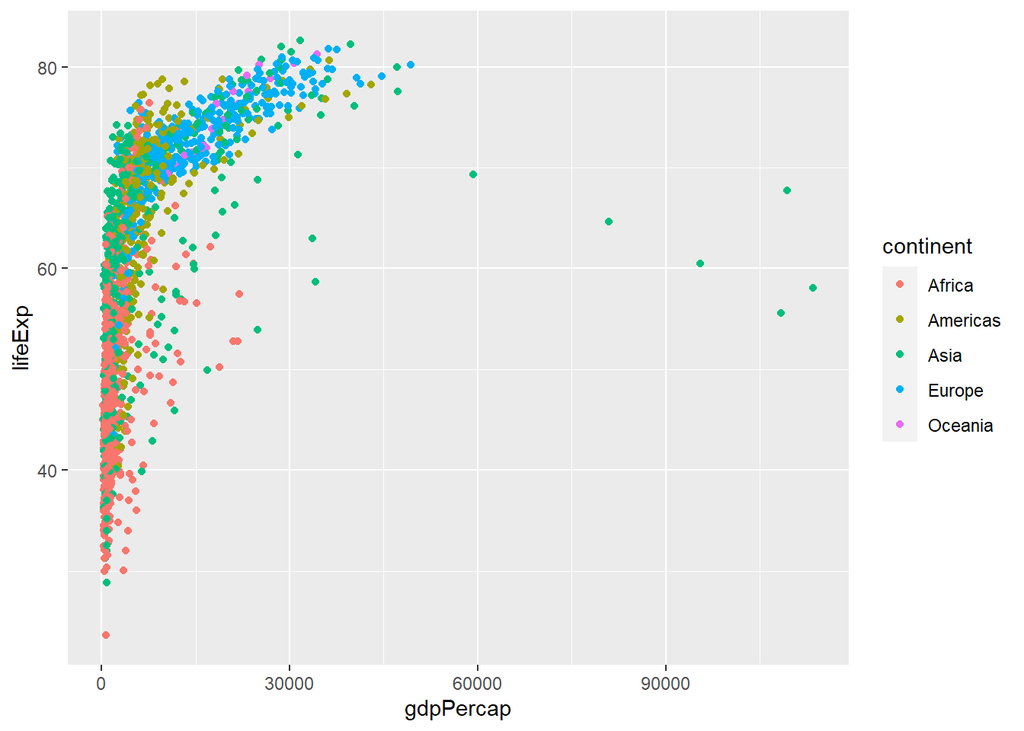

```r
ggplot(data = dat, aes(x = gdpPercap, y = lifeExp, color=continent)) + geom_point()
```

**Color** n’est pas le seul argument sur lequel nous pouvons jouer dans aes : également la taille, la forme, …

```r
ggplot(data=, aes(x=, y=, by =, color=, linetype=, shape=, size=))
```

### 2d. Layers

Pour représenter l’évolution de l’espérance de vie avec le temps, une courbe serait plus judicieuse qu’un point :

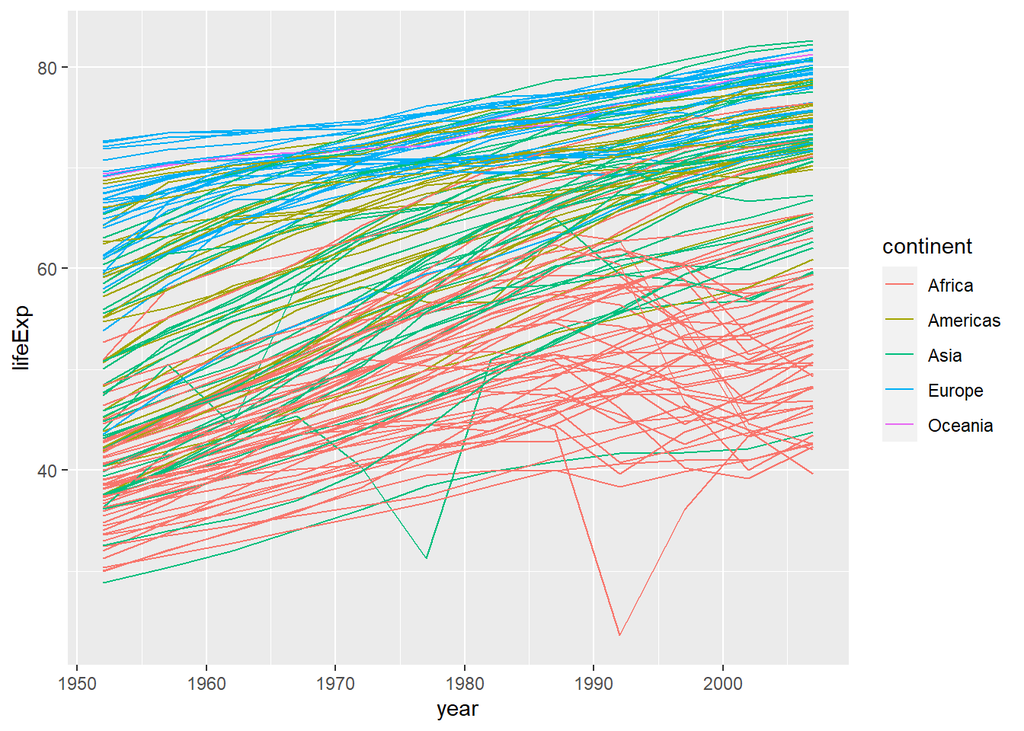

```r
ggplot(data = dat, aes(x=year, y=lifeExp, by=country, color=continent)) + geom_line()
```

Mais cumuler les deux couches est aussi possible :

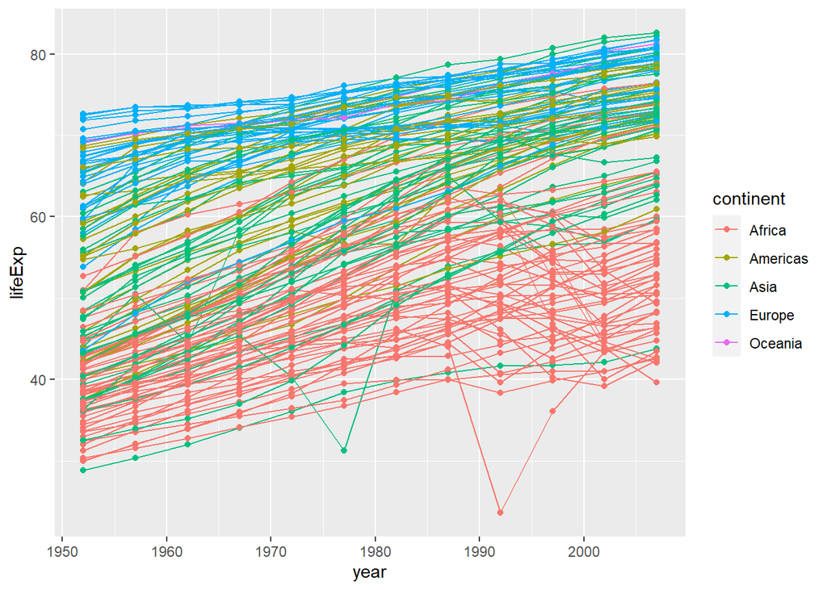

```r
ggplot(data = dat, aes(x=year, y=lifeExp, by=country, color=continent)) + geom_line() + geom_point()
```

Et chaque couche peut avoir ses paramètres aes :

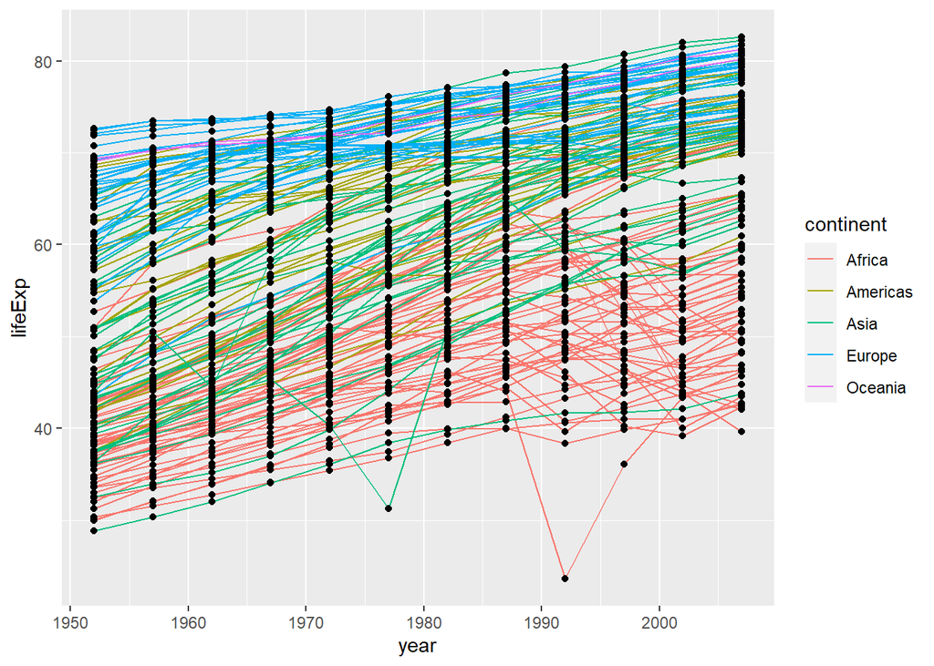

```r
ggplot(data = dat, aes(x=year, y=lifeExp, by=country)) + geom_line(aes(color=continent)) + geom_point()
```

### 2e. Titres et légendes

Les titres et légendes sont considérées comme des couches à part entière dans ggplot :

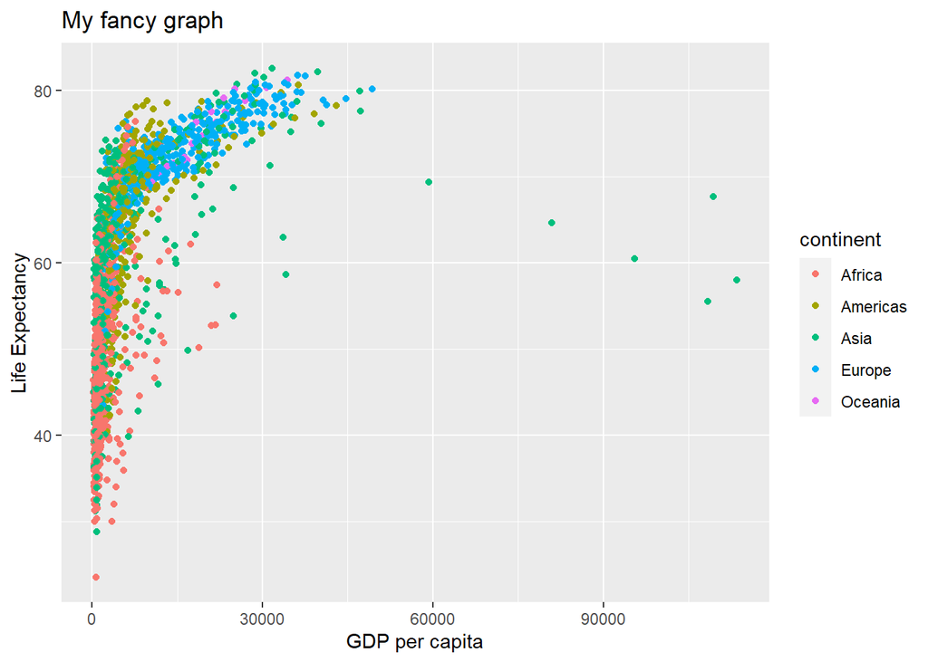

```r
# add x and y axis labels
ggplot(data = dat, aes(x = gdpPercap, y = lifeExp, color=continent)) + geom_point() + xlab("GDP per capita") + ylab("Life Expectancy") + ggtitle("My fancy graph")
```

De même que les échelles :

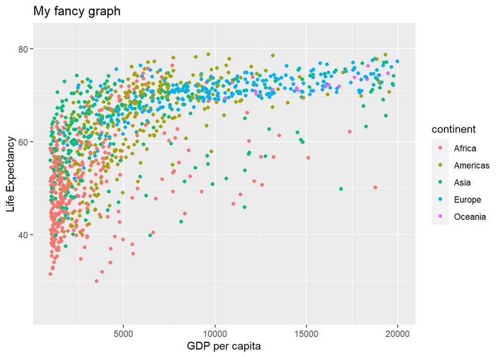

```r
# limit x axis from 1,000 to 20,000
ggplot(data = dat, aes(x = gdpPercap, y = lifeExp, color=continent)) + geom_point() + xlab("GDP per capita") + ylab("Life Expectancy") + ggtitle("My fancy graph") + xlim(1000, 20000)
```

### 2f. Transformations et Stats

Avec ggplot permet d’appliquer facilement des modèles statistiques sur les données :

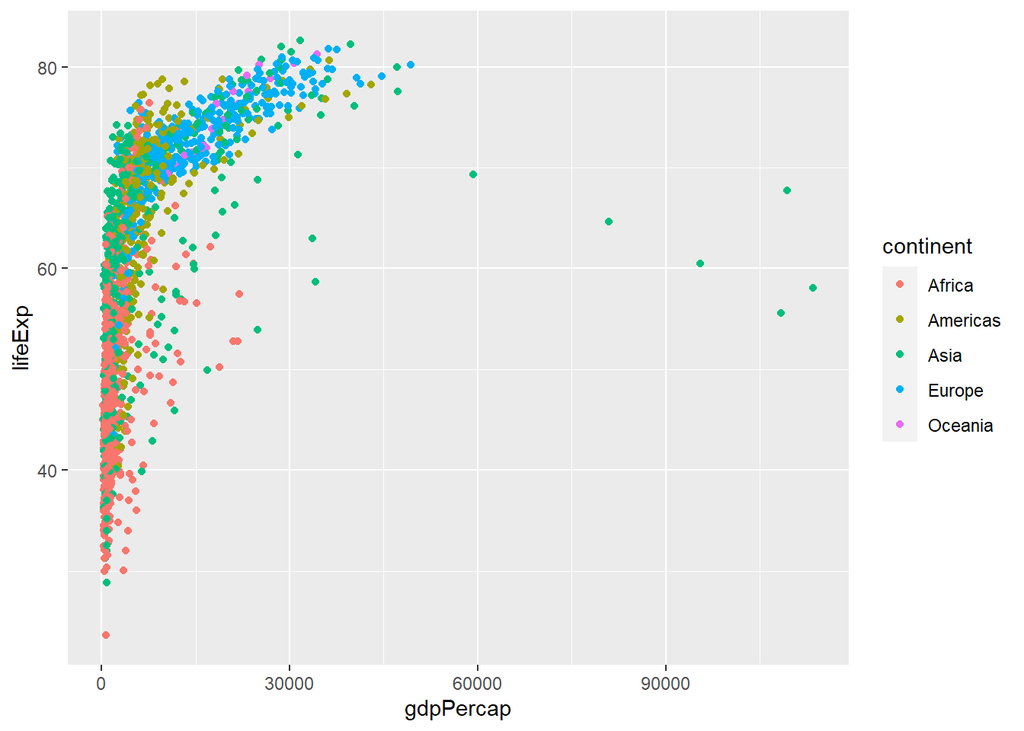

```r
ggplot(data = dat, aes(x = gdpPercap, y = lifeExp, color=continent)) + geom_point()
```

On peut par exemple changer l’échelle des abscisses pour passer en échelle log :

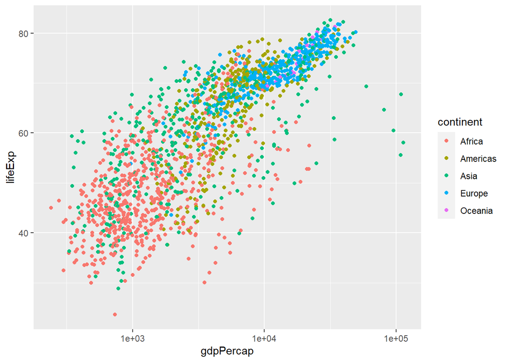

```r
ggplot(data = dat, aes(x = gdpPercap, y = lifeExp, color=continent)) + geom_point() + scale_x_log10()
```

Ici, une relation linéaire entre l’espérance de vie et le PIB par habitant semble être intéressante. On peut ajouter une relation simple en ajoutant une couche , `geom_smmoth`:

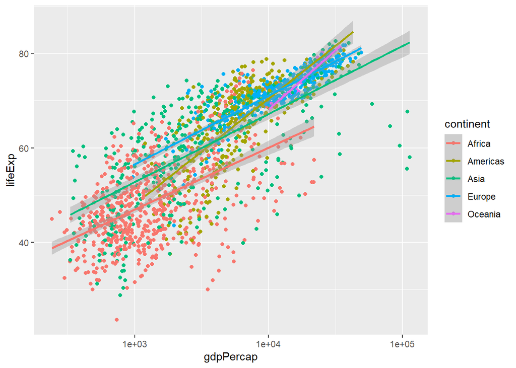

```r
ggplot(data = dat, aes(x = gdpPercap, y = lifeExp, color=continent)) + geom_point() + scale_x_log10() + geom_smooth(method="lm")
```

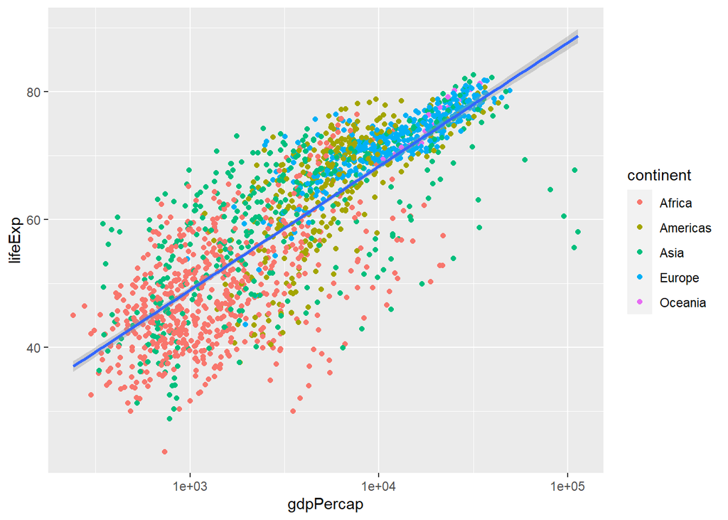

```r
ggplot(data = dat, aes(x = gdpPercap, y = lifeExp)) + geom_point(aes(color=continent)) + scale_x_log10() + geom_smooth(method="lm")
```

### 2g. Facets

Précédemment, on a vu l’évolution de l’espérance de vie avec le temps sur tous les pays sur un graphe. Il est aussi possible de séparer chaque pays en ajoutant une couche **facet** :

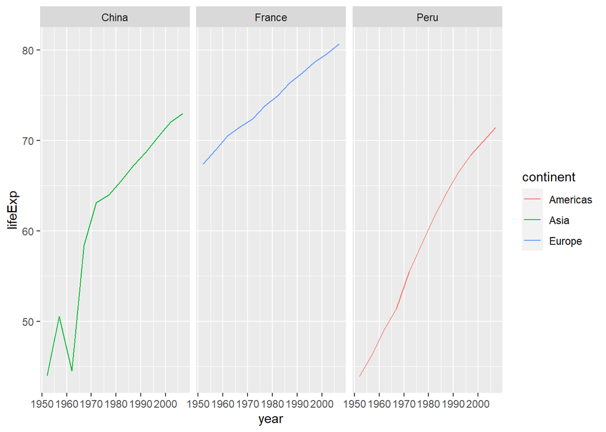

```r
ggplot(data = dat[dat$country %in% c('France', 'China', 'Peru'),], aes(x = year, y = lifeExp, color=continent)) +
  geom_line() + facet_wrap( ~ country)
```

### 2h. Putting it all together

Ceci n’est qu’une mise en bouche ! Rstudio fournit une [cheat sheet](https://www.rstudio.com/wp-content/uploads/2015/03/ggplot2-cheatsheet.pdf) très exhaustive et claire de toutes les couches disponibles sur ggplot2. Il y a forcément quelqu’un qui a essayé de tracer la même courbe que vous avant et l’a demandé à google, donc n’hésitez pas à chercher un peu si il le faut.

**bar plots**

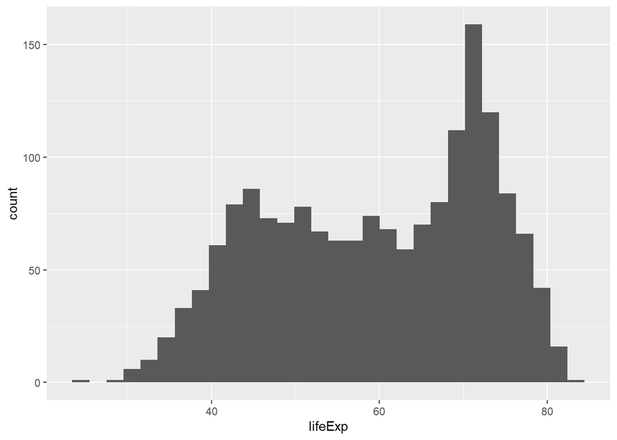

```r
# count of lifeExp bins
ggplot(data = dat, aes(x = lifeExp)) + geom_bar(stat="bin")
```

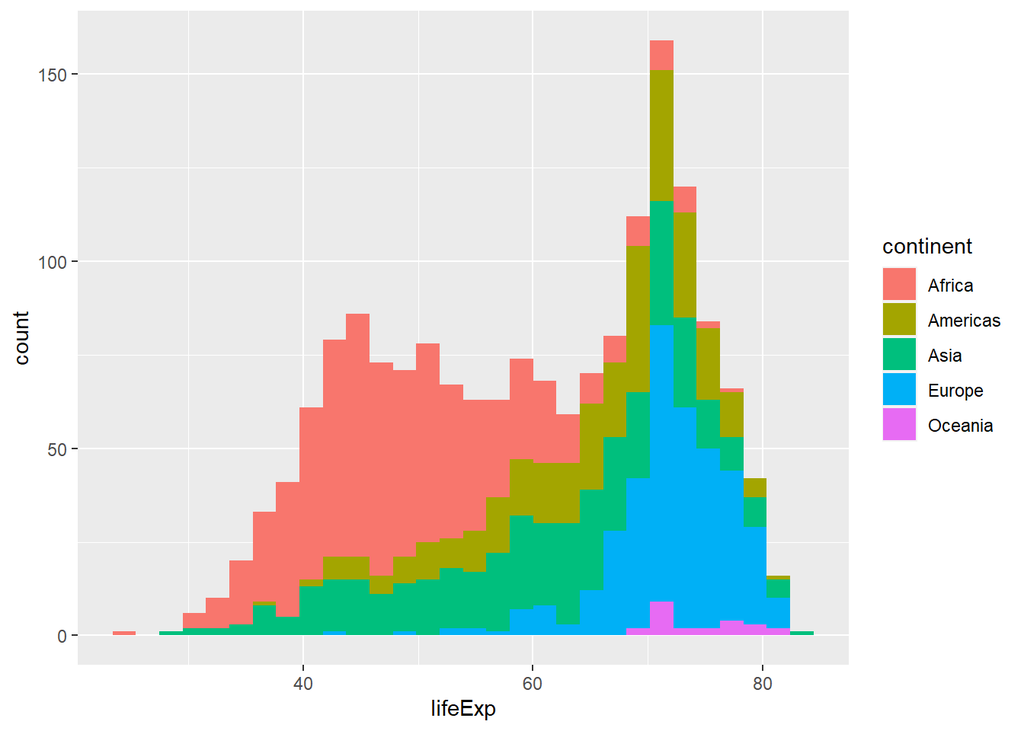

```r
# with color representing regions
ggplot(data = dat, aes(x = lifeExp, fill = continent)) + geom_bar(stat="bin")
```

**box plots**

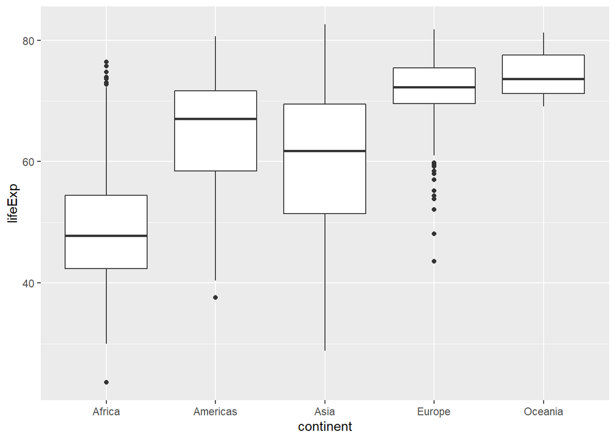

```r
ggplot(data = dat, aes(x = continent, y = lifeExp)) + geom_boxplot()
```

###. Exporting

Two basic image types

1. **Raster/Bitmap** (.png, .jpeg)

Every pixel of a plot contains its own separate coding; not so great if you want to resize the image

```r
jpeg(filename="example.png", width=, height=)
plot(x,y)
dev.off()
```

2. **Vector** (.pdf, .ps)

Every element of a plot is encoded with a function that gives its coding conditional on several factors; great for resizing

```r
pdf(filename="example.pdf", width=, height=)
plot(x,y)
dev.off()
```

**Exporting with ggplot**

```r
# Assume we saved our plot is an object called example.plot
ggsave(filename="example.pdf", plot=example.plot, scale=, width=, height=)
```